# 8050.01, Spring 2017, Homework 3 Solution

Piyali Das

Due Date: 8 March 2017

1. All problems in this homework assignment use the prostate data set described in Lecture 13. You can get the data set by downloading (and unzipping) the file `ProstateData.zip` from the Carmen web site for the course.
   1. How many probes are included in the data set? *There are 28947 probes in the dataset*

```r
load(file.path("ProstateData", "expression.data.rda"))
load(file.path("ProstateData", "clinical.info.rda"))
load(file.path("ProstateData", "gene.info.rda"))

nrow(gene.info)
```

```
## [1] 28947
```

```
b. How many unique genes are represented by those probes?
```

*There are 10204 unique genes represented here*

```r
lapply(gene.info, function(x) length(unique(x)))
```

```
## $ArrayI.Spot
## [1] 27623
##
## $ArrayII.Spot
## [1] 27807
##
## $Clone.ID
## [1] 26922
##
## $Gene.Symbol
## [1] 10204
##
## $Cluster.ID
## [1] 18030
##
## $Accession
## [1] 26808
```

```
c. How many probes are not associated with any known gene?
```

*There are 12348 probes not associated with any gene*

```r
nrow(gene.info[gene.info$Gene.Symbol == "",])
```

```
## [1] 12348
```

```
d. How many samples (in total) are studied in the data set?
```

*There are 112 samples in total*

```r
nrow(clinical.info)
```

```
## [1] 112
```

```
e. How many samples are normal? tumor? lymph node metastases?
```

*There are 41 samples that are normal, 62 tumor and 9 lymph node metastases*

```r
nrow(clinical.info[clinical.info$Status == "N",])
```

```
## [1] 41
```

```r
nrow(clinical.info[clinical.info$Status == "T",])
```

```
## [1] 62
```

```r
nrow(clinical.info[clinical.info$Status == "L",])
```

```
## [1] 9
```

2. We want to find genes that are differentially expressed between primary tumor and lymph node metastases.
   1. Create an object that contains just the tumor and lymph node samples, along with a corresponding object that identifies the classes.

```r
obj <- clinical.info[clinical.info$Status == "T" | clinical.info$Status == "L",]

xt <- which(clinical.info$Status == "T") # all tumor
xl <- which(clinical.info$Status == "L") # all normal
subdata <- expression.data[, c(xl, xt)]
subclin <- clinical.info[c(xl, xt),]
subclin$Status <- factor(subclin$Status)
```

```
b. Perform gene-by-gene t-tests to find differentially expressed genes.
Plot a histogram of the t-statistics.
```

```r
if (!require(ClassComparison)) {
  source("http://silicovore.com/OOMPA/oompaLite.R")
  oompaLite()
  library(ClassComparison)
}
```

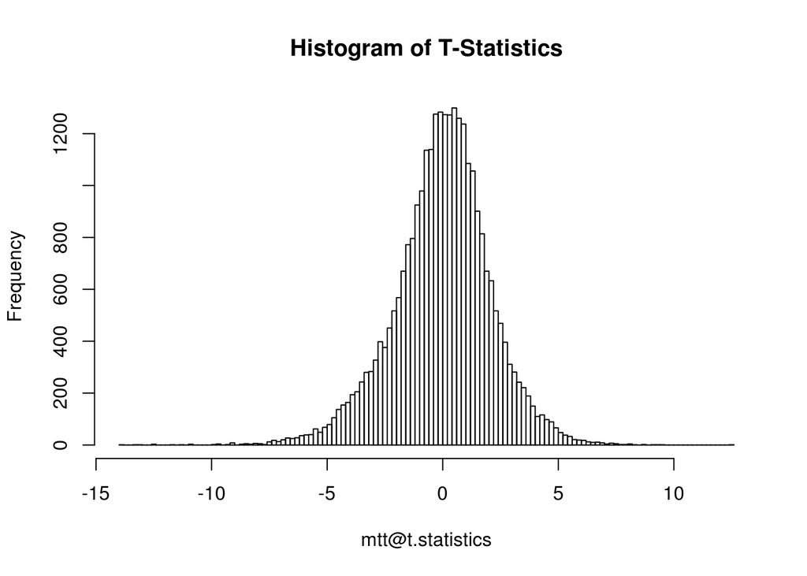

```r
mtt <- MultiTtest(subdata, subclin$Status)
hist(mtt@t.statistics,main = "Histogram of T-Statistics", breaks=100)
```

```r
summary(mtt)
```

```
## Row-by-row two-sample t-tests with 28947 rows
## Positive sign indicates an increase in class: L
##
## Call: MultiTtest(data = subdata, classes = subclin$Status)
##
## T-statistics:
##     Min.  1st Qu.   Median     Mean  3rd Qu.     Max.
## -13.9300  -1.1920   0.0812  -0.0212   1.2630  12.5800
##
## P-values:
```

```
##    Min. 1st Qu.  Median    Mean 3rd Qu.    Max.
## 0.00000 0.02926 0.22170 0.32070 0.56830 0.99990
```

```
c. Plot a histogram of the p-values.
```

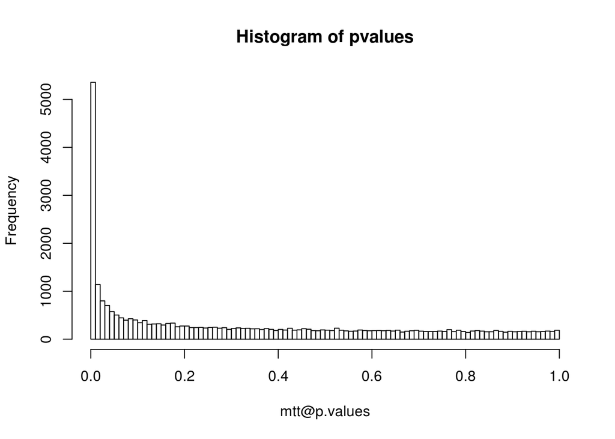

```r
hist(mtt@p.values, main = "Histogram of pvalues", breaks=100)
```

d. How many genes have p < 0.01? Is this more than you expect by chance? *There are 5358 genes with p-value <0.01. Also this is way more than is expected by chance*

```r
p.val <- mtt@p.values
sum(p.val < 0.01)
```

```
## [1] 5358
```

```r
n.genes <- nrow(subdata)
0.01 * n.genes
```

```
## [1] 289.47
```

```
e. How many genes have p < 0.05? Is this more than you expect?
```

```r
sum(p.val < 0.05)
```

```
## [1] 8574
```

```r
0.05 * n.genes
```

```
## [1] 1447.35
```

3. We want to continue with the results of the t-test analysis.
   1. Fit a beta-uniform-mixture (BUM) model to the set of p-values. Again plot a histogram of the p-values, but with the model-fitting curves superimposed.

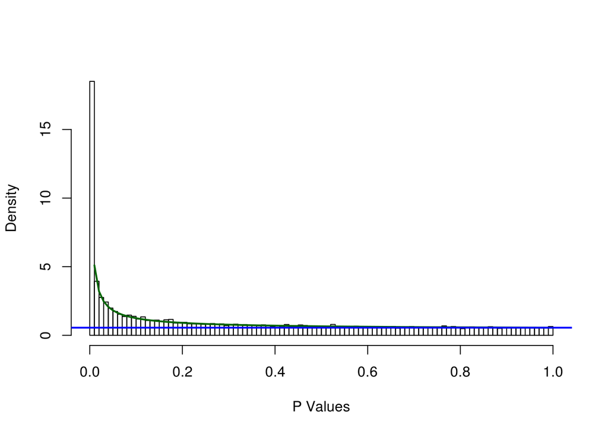

```
b. How many genes are differentially expressed at an FDR of 1%? How many at 5%?
```

```r
bum <- Bum(mtt@p.values)
hist(bum)
```

*There are 3666 genes expressed at an FDR of 1% and 6568 genes expressed at an FDR of 5%.*

```r
countSignificant(bum, alpha=0.01, by="FDR")
```

```
## [1] 3666
```

```r
countSignificant(bum, alpha=0.05, by="FDR")
```

```
## [1] 6568
```

4. Use the Wilcoxon rank-sum test to find genes that are differentially expressed between primary tumor samples and lymph node metastases.
   1. Plot a histogram of the gene-by-gene Wilcoxon rank-sum statistics.

```r
ranked.data <- apply(subdata, 1, rank)
status <- subclin[, "Status"]
ranksum <- apply(ranked.data[status == "T",], 2, sum)
summary(ranksum)
```

```
##    Min. 1st Qu.  Median    Mean 3rd Qu.    Max.
##    1956    2158    2227    2231    2302    2511
```

```r
par(mfrow=c(1,2))
hist(ranksum, breaks = seq(1900, 2600, by = 10), main = "Ranksum of Tumor node")
ranksum1 <- apply(ranked.data[status == "L",], 2, sum)
summary(ranksum1)
```

```
##    Min. 1st Qu.  Median    Mean 3rd Qu.    Max.
##    45.0   254.0   329.0   324.8   398.0   600.0
```

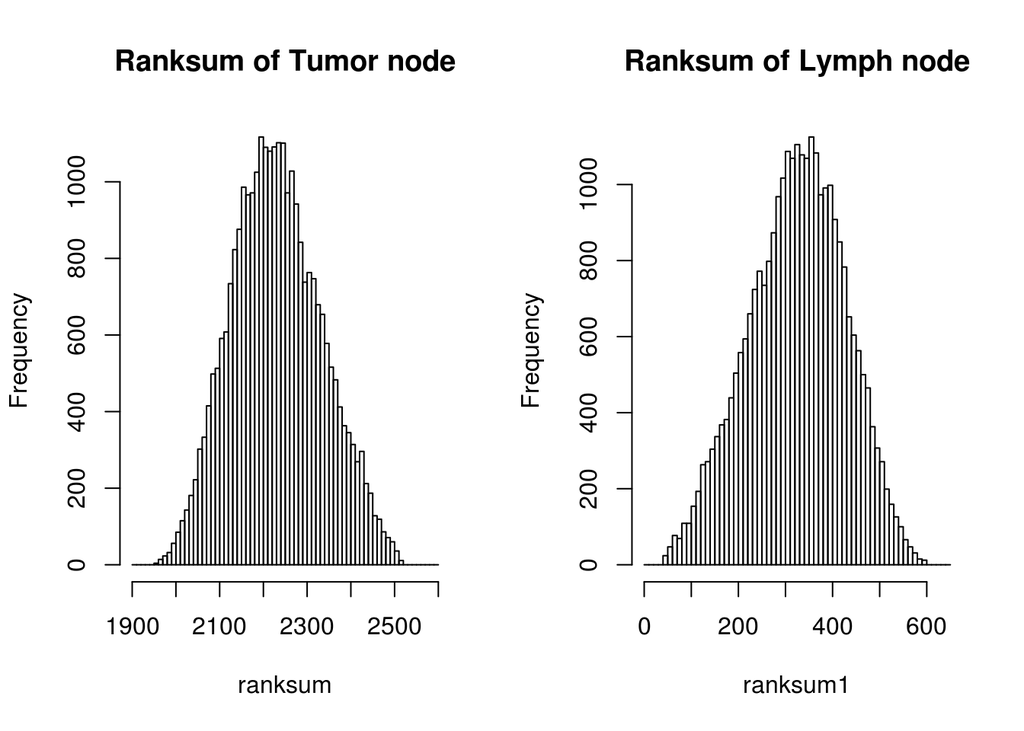

```
b. We want to apply the empirical Bayes method. By trial-and-error, find a
value (to two decimal places) for the prior probability $p_0$ (that a gene is not
differentially expressed) that ensures that the posterior probabilities are
never negative.
```

```r
hist(ranksum1, breaks = seq(0, 650, by = 10), main = "Ranksum of Lymph node")
```

*prior probability of 0.52 ensures non -ve posterior probabilities*

```r
require(ClassComparison)
efron <- MultiWilcoxonTest(subdata, status)
```

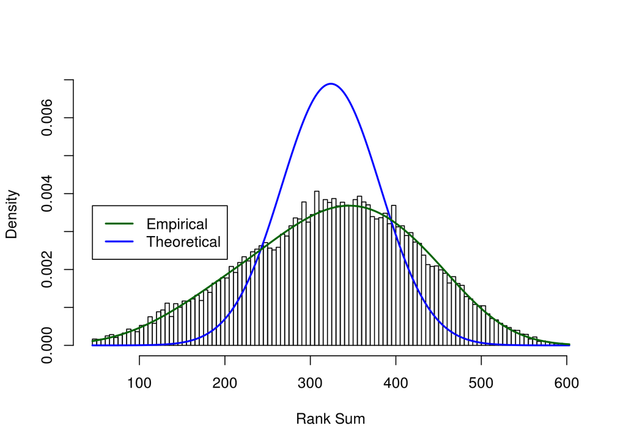

```r
hist(efron)
```

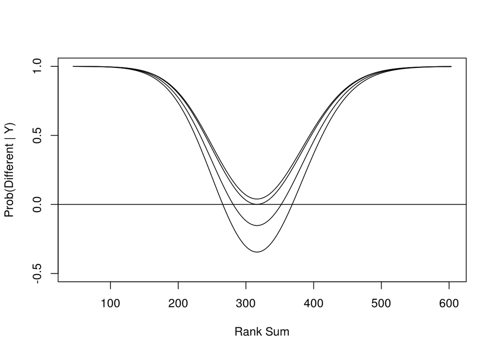

```r
plot(efron, prior=c(0.5,0.52,0.6,0.7 ), signif=NULL)
abline(h=0)
```

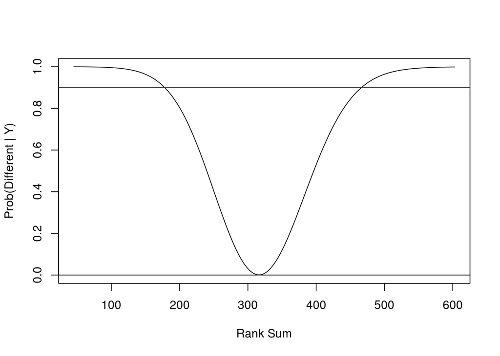

```
c. Using that value of $p_0$, determine how many genes are differentially
expressed with a posterior probability of 90%. How many are higher in lymph
nodes and how many are higher in primary tumors?
```

```r
plot(efron, prior=0.52, ylim=c(0,1))
abline(h=0)
```

*2362 are higher in lymph nodes, and 2640 are higher in primary tumors.*

```r
cutoffSignificant(efron, prior=0.52, signif=0.9)
```

```
## $low
## [1] 179
##
## $high
## [1] 466
```

```r
summary(efron, prior=0.52)
```

```
## Call: MultiWilcoxonTest(data = subdata, classes = status)
## Row-by-row Wilcoxon rank-sum tests with 28947 rows
##
## Rank-sum statistics:
##    Min. 1st Qu.  Median    Mean 3rd Qu.    Max.
##    45.0   254.0   329.0   324.8   398.0   600.0
##
## Large values indicate an increase in class: L
##
## With prior = 0.52 and alpha = 0.9
##  the upper tail contains 2362 values above 466
##  the lower tail contains 2640 values below 179
```

5. Now we want to return to the complete prostate cancer data set and look at possible confounding factors. (Of course, we should have done this first….)
   1. Apply the `summary` command to the clinical information, and note that there is a `ChipType` column that might represent an important technological factor. How many samples of each histology (N, T, L) were run on each chip type? Is there any reason to think that the sample histologies were confounded with chip type?

*For ChipType = “new” there was L:5 N:32 T:49*  
*For ChipType = “old” there was L:4 N:9 T:13* *On doing clustering analysis of the data it seems like the histology was distributed differently in old chip type and new chip type*

```r
summary(clinical.info)
```

```
##      Arrays      Reference       Sample    Status Subgroups ChipType
##  p16090 :  1   CRG1   :  1   PL114  :  1   L: 9   I  :11    new:86
##  p16093 :  1   CRG10  :  1   PL115  :  1   N:41   II :39    old:26
##  p16095 :  1   CRG100 :  1   PL116  :  1   T:62   III:19
##  p16097 :  1   CRG101 :  1   PL118.3:  1          N  :41
##  p16098 :  1   CRG102 :  1   PL122  :  1          O  : 2
##  p16101 :  1   CRG103 :  1   PL129  :  1
##  (Other):106   (Other):106   (Other):106
```

```r
obj1 <- clinical.info[clinical.info$ChipType == "new",]
table(obj1$Status)
```

```
##
##  L  N  T
##  5 32 49
```

```r
obj2 <- clinical.info[clinical.info$ChipType == "old",]
table(obj2$Status)
```

```
##
##  L  N  T
##  4  9 13
```

2. Using hierarchical clustering and principal components analysis, try to assess visually if the sample histology or the chip type has a bigger overall impact on the data. *For hierarchical clustering, the chip type has bigger impact as the new and the old types are grouped together, whereas in PCA both histology and chip type are of equal weightage*

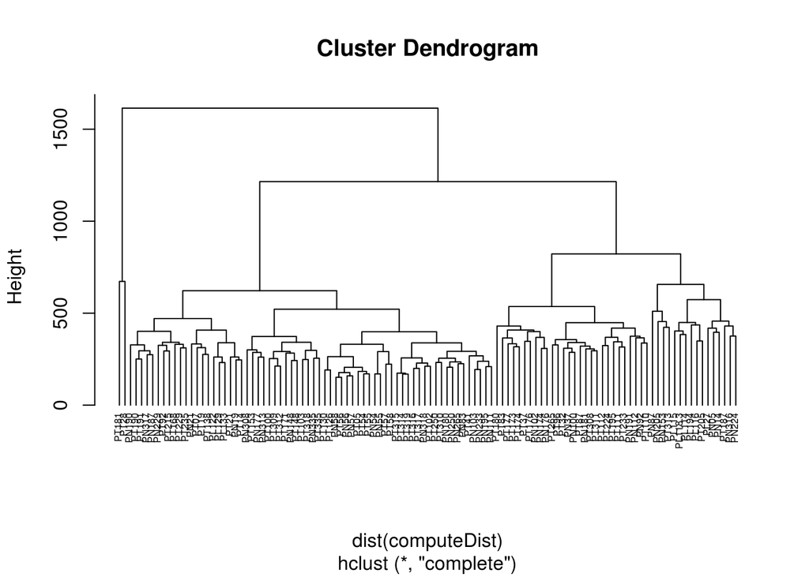

```r
computeDist = dist(t(expression.data), method = "euclidean", diag = FALSE, upper = FALSE, p = 2)
clusters <- hclust(dist(computeDist))
plot(clusters, hang=-1, cex= 0.5)
```

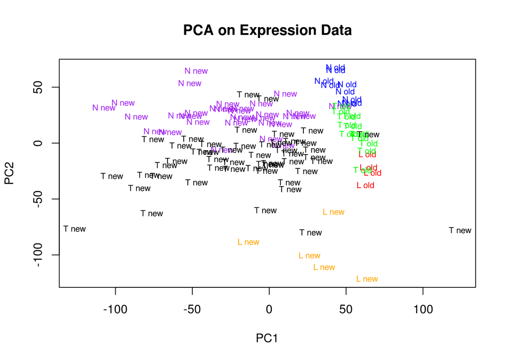

```r
mycol=rep("red", length(clinical.info$Status))
mycol[which(clinical.info$Status=="L" & clinical.info$ChipType == "old")]="red"
mycol[which(clinical.info$Status=="N" & clinical.info$ChipType == "old")]="blue"
mycol[which(clinical.info$Status=="T" & clinical.info$ChipType == "old")]="green"
mycol[which(clinical.info$Status=="L" & clinical.info$ChipType == "new")]="orange"
mycol[which(clinical.info$Status=="N" & clinical.info$ChipType == "new")]="purple"
mycol[which(clinical.info$Status=="T" & clinical.info$ChipType == "new")]="black"
prostatePca = prcomp(t(expression.data))
plot(prostatePca$x[,1:2], pch="", main="PCA on Expression Data")
text(prostatePca$x, labels = paste(clinical.info$Status,clinical.info$ChipType), cex=.7,col=mycol)
```

6. Now we want to consider all three sample categories.
   1. Perform gene-by-gene analysis of variance (ANOVA) to find genes that are differentially expressed between at least two of the three sample groups.

```r
statusModel = MultiLinearModel(Y ~ clinical.info$Status, clinical.info, expression.data)
nullModel = MultiLinearModel(Y ~ 1, clinical.info, expression.data)
statusEffect = anova(nullModel, statusModel)
summary(statusEffect)
```

```
##   F.statistics          p.values
##  Min.   :  0.00009   Min.   :0.000000
##  1st Qu.:  0.85632   1st Qu.:0.002589
##  Median :  2.36873   Median :0.098358
##  Mean   :  5.59275   Mean   :0.243168
##  3rd Qu.:  6.29108   3rd Qu.:0.427535
##  Max.   :205.75245   Max.   :0.999906
```

```
b. Fit a beta-uniform-mixture model to the set of p-values and plot a histogram
of the results.
```

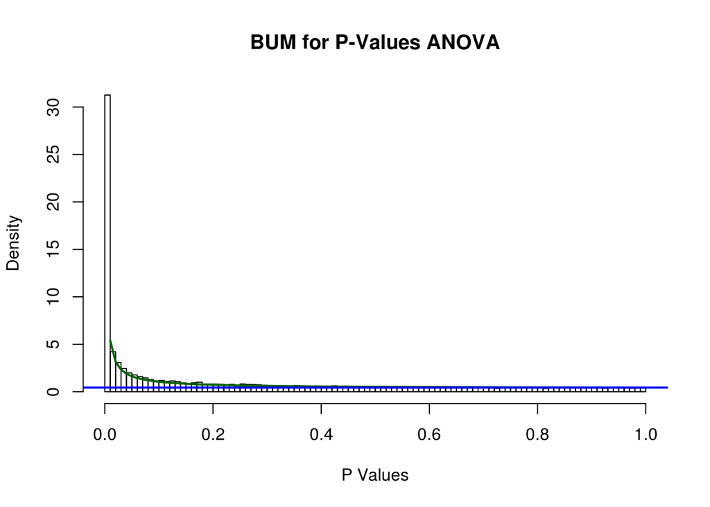

```r
statusEffectBum = Bum(statusEffect$p.values)
hist(statusEffectBum, main = "BUM for P-Values ANOVA")
```

c. How many gens are significant when FDR=1%? How many at 5%? How many at 10%? *when FDR = 1%: 8610 genes are significant, when FDR = 5%: 12530 , when FDR = 10% 15270 genes are significant.*

```r
countSignificant(statusEffectBum, alpha=0.01, by="FDR")
```

```
## [1] 8610
```

```r
countSignificant(statusEffectBum, alpha=0.05, by="FDR")
```

```
## [1] 12530
```

```r
countSignificant(statusEffectBum, alpha=0.10, by="FDR")
```

```
## [1] 15270
```

7. Fit a linear model that includes both ChipType and Status (histology) as factors that explain the gene expression data.
   1. Use ANOVA to compare this model to the model in Problem 6 that only considers the Status. How many genes change significantly due to ChipType after adjusting for Status when FDR=1%? *7967 got changed due to ChipType adjustment*

```r
chipModel = MultiLinearModel(Y ~ clinical.info$Status + clinical.info$ChipType, clinical.info, expression.data)
effect_anova = anova(statusModel, chipModel)
effect_pvalues = Bum(effect_anova$p.values)
countSignificant(effect_pvalues, alpha=0.01, by="FDR")
```

```
## [1] 7967
```

```
b. Fit another model that only uses ChipType to explain the gene expression data.
By comparing this model to the full model in (a), find out how many genes change
significantly by Status after adjusting for ChipType when FDR=1%.
```

```r
chipModel1 = MultiLinearModel(Y ~ clinical.info$ChipType, clinical.info, expression.data)
new_effect_anova = anova(chipModel1, chipModel)
new_effect_pvalues = Bum(new_effect_anova$p.values)
countSignificant(new_effect_pvalues, alpha = 0.01, by = "FDR")
```

```
## [1] 8818
```

```
c. Now do you think that ChipType or Status is the more important factor?
```

*Status seems to be more important factor*